# Blood Pressure Abnormality Prediction

Arpit Gupta (arpit.gupta2008@gmail.com)

30 September 2018

### *Background*

Hypertension with aging is a major medical concern even in this ultramodern era of advanced therapies. Preliminary testing is a key element in analyzing the procedures of mild abnormality of blood pressure for a substantial period of time, but presently has a limited value in the prediction of progression to hypertension. Although hypotension, low blood pressure in common parlance, is less common among the ones with abnormal blood pressure, but the adverse effect it has on their health is equivalent to that of hypertension.

Although recent studies have hypothesized that, keeping other factors constant, hemoglobin level is positively associated with blood pressure in a large cohort of healthy individuals, but genetic causes are also prominent in some of individuals. However, there are numerous other factors which determine whether an individual is likely to develop this abnormality.

### *Objective*

Employing statistical techniques, conduct a preliminary prognosis of Hypertension/hypotension.

#### Loading Required packages

```r
list.of.packages <- c("tidyverse","MASS","car", "caret","cowplot","caTools","pROC","ggcorrplot", "corrplot", "rpart","rpart.plot","randomForest")
new.packages <- list.of.packages[!(list.of.packages %in% installed.packages()[,"Package"])]
if (length(new.packages)) {install.packages(new.packages)}

t<-sapply(list.of.packages,library, character.only =T)
rm(t)
```

#### Load Blood Pressure Data

```r
df<- read.csv("Training Data - Classification of Patients with Abnormal Blood Pressure (N=2000)_27-Jul-2016.csv")
glimpse(df)
```

```
## Observations: 2,000
## Variables: 15
## $ Patient_Number                <int> 1, 2, 3, 4, 5, 6, 7, 8, 9, 10, 1...
## $ Blood_Pressure_Abnormality    <int> 1, 0, 1, 0, 1, 0, 1, 0, 0, 1, 1,...
## $ Level_of_Hemoglobin           <dbl> 11.28, 9.75, 10.79, 11.00, 14.17...
## $ Genetic_Pedigree_Coefficient  <dbl> 0.90, 0.23, 0.91, 0.43, 0.83, 0....
## $ Age                           <int> 34, 54, 70, 71, 52, 23, 43, 48, ...
## $ BMI                           <int> 23, 33, 49, 50, 19, 48, 41, 20, ...
## $ Sex                           <int> 1, 1, 0, 0, 0, 0, 1, 0, 0, 0, 1,...
## $ Pregnancy                     <int> 1, NA, NA, NA, NA, NA, 1, NA, NA...
## $ Smoking                       <int> 0, 0, 0, 0, 0, 1, 0, 0, 0, 0, 0,...
## $ Physical_activity             <int> 45961, 26106, 9995, 10635, 15619...
## $ salt_content_in_the_diet      <int> 48071, 25333, 29465, 7439, 49644...
## $ alcohol_consumption_per_day   <int> NA, 205, 67, 242, 397, NA, 206, ...
## $ Level_of_Stress               <int> 2, 3, 2, 1, 2, 3, 3, 2, 3, 2, 1,...
## $ Chronic_kidney_disease        <int> 1, 0, 1, 1, 0, 0, 1, 0, 0, 0, 1,...
## $ Adrenal_and_thyroid_disorders <int> 1, 0, 0, 0, 0, 0, 1, 0, 0, 0, 1,...
```

Replacing null with 0

```r
df[is.na(df)]<-0  # replace all null with 0
```

## Exploratory Data Analysis

- Blood_Pressure_Abnormality columns tells us about the number of Customers who suffered from hypertension.
- Around 49% of customers suffered from hypertension:

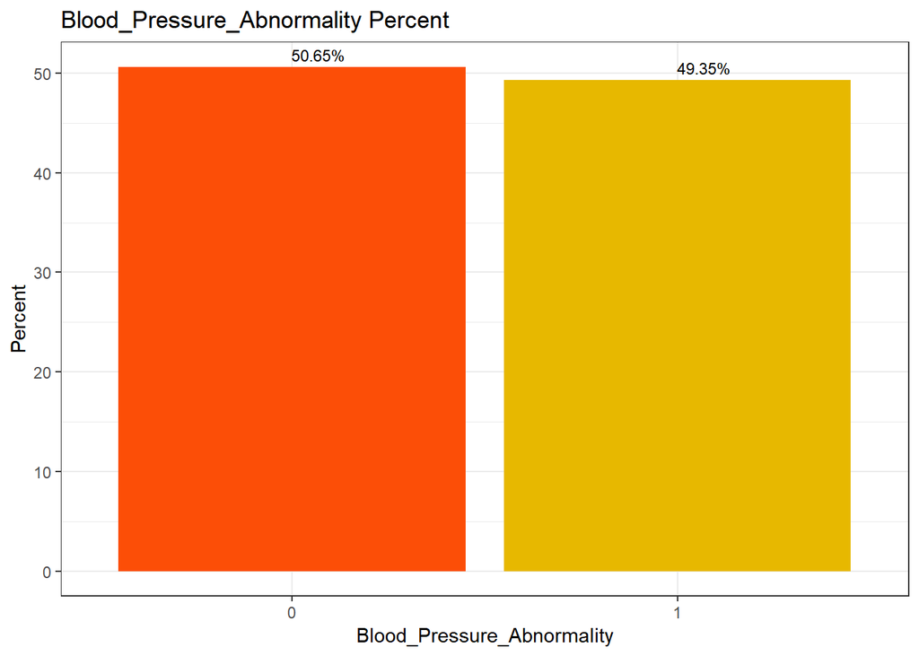

```r
df %>%
  group_by(Blood_Pressure_Abnormality) %>%
  summarise(Count = n())%>%
  mutate(percent = prop.table(Count)*100)%>%
  ggplot(aes(reorder(Blood_Pressure_Abnormality, -percent), percent), fill = Blood_Pressure_Abnormality)+
  geom_col(fill = c("#FC4E07", "#E7B800"))+
  geom_text(aes(label = sprintf("%.2f%%", percent)), hjust = 0.01,vjust = -0.5, size =3)+
  theme_bw()+
  xlab("Blood_Pressure_Abnormality") +
  ylab("Percent")+
  ggtitle("Blood_Pressure_Abnormality Percent")
```

#### Check for collinearity

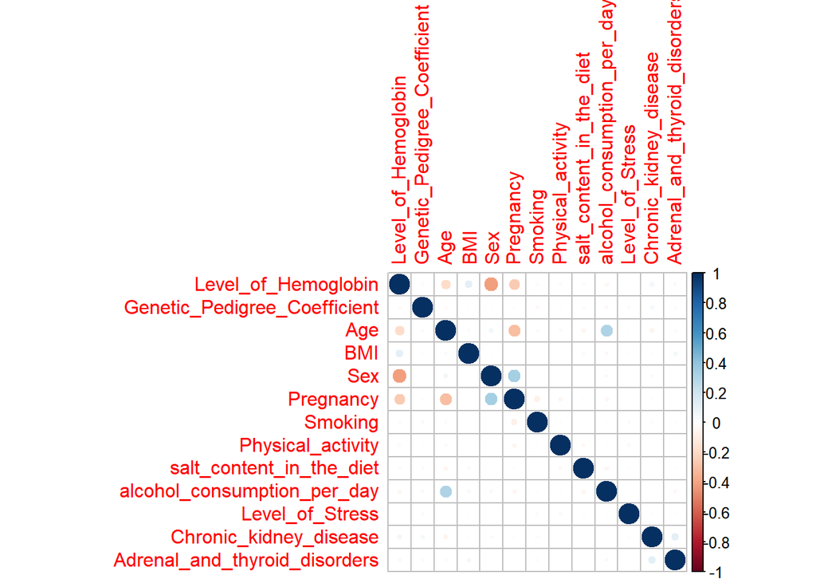

```r
corrplot(cor(df[sapply(df[,-c(1:2)], is.numeric),-c(1:2)]))
```

```r
df_factor_variables<- c("Blood_Pressure_Abnormality","Sex","Pregnancy","Smoking","Level_of_Stress",
                        "Chronic_kidney_disease","Adrenal_and_thyroid_disorders")

df[df_factor_variables]<- as.data.frame(lapply(df[df_factor_variables], as.factor))
```

#### Visualising Categorical Data

- Gender- Male have slightly higher chances of suffering from hypertension
- People with chronic kidney disease or adrenal & thyriod disorders have higher rate of suffering from hypertension.

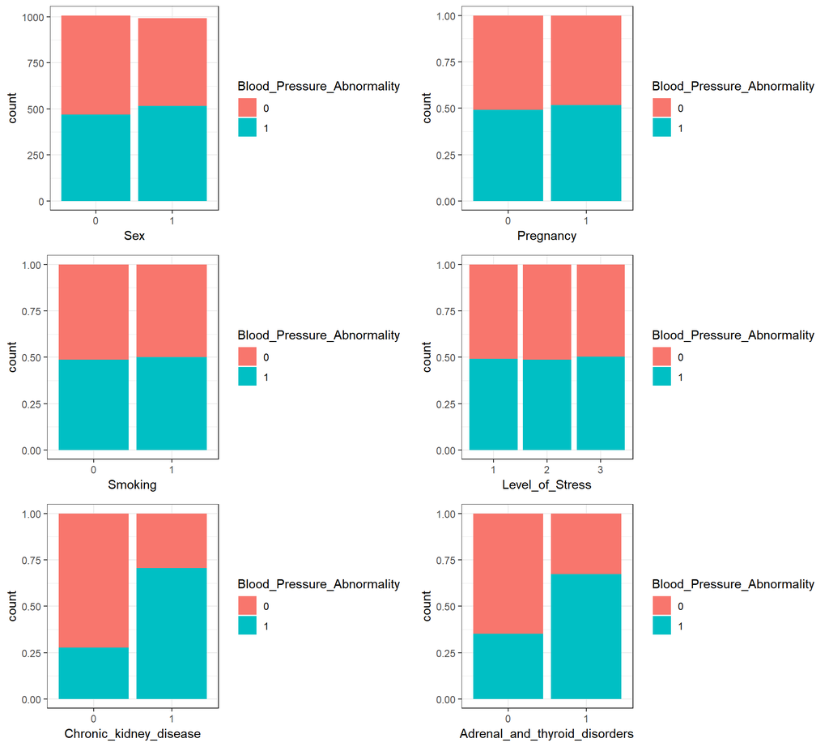

```r
options(repr.plot.width = 12, repr.plot.height = 10)
plot_grid(ggplot(df, aes(x=Sex,fill=Blood_Pressure_Abnormality))+ geom_bar()+ theme_bw(),
          ggplot(df, aes(x=Pregnancy,fill=Blood_Pressure_Abnormality))+ geom_bar(position = 'fill')+theme_bw(),
          ggplot(df, aes(x=Smoking,fill=Blood_Pressure_Abnormality))+ geom_bar(position = 'fill')+theme_bw(),
          ggplot(df, aes(x=Level_of_Stress ,fill=Blood_Pressure_Abnormality))+ geom_bar(position = 'fill')+theme_bw(),
          ggplot(df, aes(x=Chronic_kidney_disease,fill=Blood_Pressure_Abnormality))+ geom_bar(position = 'fill')+theme_bw(),
          ggplot(df, aes(x=Adrenal_and_thyroid_disorders ,fill=Blood_Pressure_Abnormality))+ geom_bar(position = 'fill')+theme_bw()+
          scale_x_discrete(labels = function(x) str_wrap(x, width = 10)),
          align = "h", nrow = 3)
```

#### Visualising continuous data

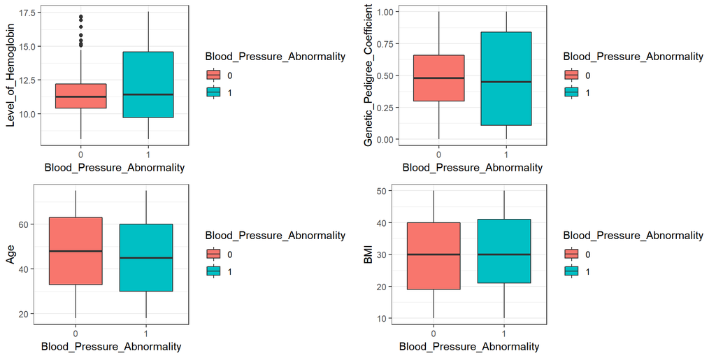

```r
options(repr.plot.width = 12, repr.plot.height = 10)
plot_grid(ggplot(df, aes(Blood_Pressure_Abnormality, Level_of_Hemoglobin,fill=Blood_Pressure_Abnormality))+ geom_boxplot()+ theme_bw(),
          ggplot(df, aes(Blood_Pressure_Abnormality, Genetic_Pedigree_Coefficient,fill=Blood_Pressure_Abnormality))+ geom_boxplot()+ theme_bw(),
          ggplot(df, aes(Blood_Pressure_Abnormality, Age,fill=Blood_Pressure_Abnormality))+ geom_boxplot()+ theme_bw(),
          ggplot(df, aes(Blood_Pressure_Abnormality, BMI,fill=Blood_Pressure_Abnormality))+ geom_boxplot()+ theme_bw()+
           scale_x_discrete(labels = function(x) str_wrap(x, width = 10)),
          align = "h", ncol = 2)
```

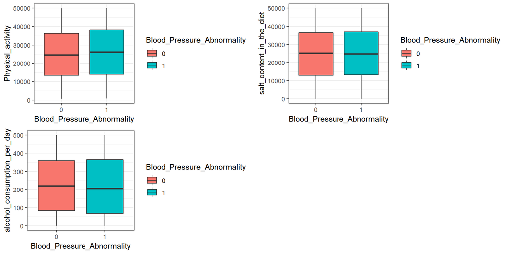

```r
options(repr.plot.width = 12, repr.plot.height = 10)
plot_grid(ggplot(df, aes(Blood_Pressure_Abnormality, Physical_activity,fill=Blood_Pressure_Abnormality))+ geom_boxplot()+ theme_bw(),
          ggplot(df, aes(Blood_Pressure_Abnormality, salt_content_in_the_diet,fill=Blood_Pressure_Abnormality))+ geom_boxplot()+ theme_bw(),
          ggplot(df, aes(Blood_Pressure_Abnormality, alcohol_consumption_per_day,fill=Blood_Pressure_Abnormality))+ geom_boxplot()+ theme_bw()+
           scale_x_discrete(labels = function(x) str_wrap(x, width = 10)),
          align = "h", ncol = 2)
```

```r
num_columns<- c("Level_of_Hemoglobin","Age","BMI","Physical_activity","salt_content_in_the_diet","alcohol_consumption_per_day")
df_cor <- round(cor(df[,num_columns]), 1)
# ggcorrplot(df_cor,  title = "Correlation")+theme(plot.title = element_text(hjust = 0.5))
```

#### Preparing the data

```r
df_final<- df
df_final<- df[,-1]
```

```r
#Splitting the data
set.seed(123)
indices = sample.split(df_final$Blood_Pressure_Abnormality, SplitRatio = 0.7)
train = df_final[indices,]
validation = df_final[!(indices),]
```

## Model Building 1 - Logistic Regression

```r
#Build the first model using all variables
model_1 = glm(Blood_Pressure_Abnormality ~ ., data = train, family = "binomial")
summary(model_1)
```

```
##
## Call:
## glm(formula = Blood_Pressure_Abnormality ~ ., family = "binomial",
##     data = train)
##
## Deviance Residuals:
##     Min       1Q   Median       3Q      Max
## -2.3858  -0.7792  -0.3937   0.8472   2.3016
##
## Coefficients:
##                                  Estimate Std. Error z value Pr(>|z|)
## (Intercept)                    -4.265e+00  5.984e-01  -7.126 1.03e-12 ***
## Level_of_Hemoglobin             1.987e-01  3.509e-02   5.663 1.48e-08 ***
## Genetic_Pedigree_Coefficient   -1.199e-01  2.123e-01  -0.565   0.5721
## Age                            -2.198e-03  4.307e-03  -0.510   0.6099
## BMI                            -1.111e-02  5.528e-03  -2.009   0.0445 *
## Sex1                            6.030e-01  1.487e-01   4.054 5.03e-05 ***
## Pregnancy1                      1.833e-01  2.471e-01   0.742   0.4581
## Smoking1                        1.681e-01  1.295e-01   1.298   0.1944
## Physical_activity               8.837e-06  4.589e-06   1.926   0.0541 .
## salt_content_in_the_diet        2.216e-06  4.580e-06   0.484   0.6285
## alcohol_consumption_per_day    -5.770e-05  4.298e-04  -0.134   0.8932
## Level_of_Stress2                1.469e-01  1.592e-01   0.923   0.3560
## Level_of_Stress3                9.155e-02  1.559e-01   0.587   0.5571
## Chronic_kidney_disease1         1.925e+00  1.316e-01  14.628  < 2e-16 ***
## Adrenal_and_thyroid_disorders1  1.580e+00  1.329e-01  11.891  < 2e-16 ***
## ---
## Signif. codes:  0 '***' 0.001 '**' 0.01 '*' 0.05 '.' 0.1 ' ' 1
##
## (Dispersion parameter for binomial family taken to be 1)
##
##     Null deviance: 1940.6  on 1399  degrees of freedom
## Residual deviance: 1465.1  on 1385  degrees of freedom
## AIC: 1495.1
##
## Number of Fisher Scoring iterations: 4
```

Using stepAIC for variable selection, which is a iterative process of adding or removing variables, in order to get a subset of variables that gives the best performing model.

```r
model_2<- stepAIC(model_1, direction="both")
```

```r
summary(model_2)
```

```
##
## Call:
## glm(formula = Blood_Pressure_Abnormality ~ Level_of_Hemoglobin +
##     BMI + Sex + Physical_activity + Chronic_kidney_disease +
##     Adrenal_and_thyroid_disorders, family = "binomial", data = train)
##
## Deviance Residuals:
##     Min       1Q   Median       3Q      Max
## -2.4090  -0.7840  -0.4059   0.8608   2.2935
##
## Coefficients:
##                                  Estimate Std. Error z value Pr(>|z|)
## (Intercept)                    -4.207e+00  4.789e-01  -8.784  < 2e-16 ***
## Level_of_Hemoglobin             1.990e-01  3.372e-02   5.901 3.62e-09 ***
## BMI                            -1.097e-02  5.493e-03  -1.998   0.0458 *
## Sex1                            6.388e-01  1.434e-01   4.456 8.35e-06 ***
## Physical_activity               8.430e-06  4.560e-06   1.848   0.0645 .
## Chronic_kidney_disease1         1.918e+00  1.307e-01  14.675  < 2e-16 ***
## Adrenal_and_thyroid_disorders1  1.579e+00  1.325e-01  11.923  < 2e-16 ***
## ---
## Signif. codes:  0 '***' 0.001 '**' 0.01 '*' 0.05 '.' 0.1 ' ' 1
##
## (Dispersion parameter for binomial family taken to be 1)
##
##     Null deviance: 1940.6  on 1399  degrees of freedom
## Residual deviance: 1469.3  on 1393  degrees of freedom
## AIC: 1483.3
##
## Number of Fisher Scoring iterations: 4
```

We can use variance inflation factor (vif) to get rid of redundant predictors or the variables that have high multicollinearity between them. Multicollinearity exists when two or more predictor variables are highly related to each other and then it becomes difficult to understand the impact of an independent variable on the dependent variable.

The Variance Inflation Factor(VIF) is used to measure the multicollinearity between predictor variables in a model. A predictor having a VIF of 2 or less is generally considered safe and it can be assumed that it is not correlated with other predictor variables. Higher the VIF, greater is the correlation of the predictor variable w.r.t other predictor variables. However, Predictors with high VIF may have high p-value(or highly significant), hence, we need to see the significance of the Predictor variable before removing it from our model.

```r
vif(model_2)
```

```
##           Level_of_Hemoglobin                           BMI
##                      1.274340                      1.029061
##                           Sex             Physical_activity
##                      1.253783                      1.005534
##        Chronic_kidney_disease Adrenal_and_thyroid_disorders
##                      1.042058                      1.049911
```

```r
#Removing Physical_activity due to high p-value
model_3 <-glm(formula = Blood_Pressure_Abnormality ~ Level_of_Hemoglobin + BMI + Sex +
                 Chronic_kidney_disease + Adrenal_and_thyroid_disorders
              , family = "binomial", data = train)
summary(model_3)
```

```
##
## Call:
## glm(formula = Blood_Pressure_Abnormality ~ Level_of_Hemoglobin +
##     BMI + Sex + Chronic_kidney_disease + Adrenal_and_thyroid_disorders,
##     family = "binomial", data = train)
##
## Deviance Residuals:
##     Min       1Q   Median       3Q      Max
## -2.4039  -0.7884  -0.4128   0.8607   2.3377
##
## Coefficients:
##                                 Estimate Std. Error z value Pr(>|z|)
## (Intercept)                    -3.950679   0.456015  -8.663  < 2e-16 ***
## Level_of_Hemoglobin             0.195722   0.033610   5.823 5.77e-09 ***
## BMI                            -0.010974   0.005491  -1.999   0.0456 *
## Sex1                            0.634516   0.143115   4.434 9.27e-06 ***
## Chronic_kidney_disease1         1.915825   0.130456  14.686  < 2e-16 ***
## Adrenal_and_thyroid_disorders1  1.573253   0.132129  11.907  < 2e-16 ***
## ---
## Signif. codes:  0 '***' 0.001 '**' 0.01 '*' 0.05 '.' 0.1 ' ' 1
##
## (Dispersion parameter for binomial family taken to be 1)
##
##     Null deviance: 1940.6  on 1399  degrees of freedom
## Residual deviance: 1472.8  on 1394  degrees of freedom
## AIC: 1484.8
##
## Number of Fisher Scoring iterations: 4
```

```r
vif(model_3)
```

```
##           Level_of_Hemoglobin                           BMI
##                      1.270395                      1.029069
##                           Sex        Chronic_kidney_disease
##                      1.252885                      1.041360
## Adrenal_and_thyroid_disorders
##                      1.048132
```

```r
final_model <- model_2
```

#### Model Evaluation using the validation data:

```r
pred <- predict(final_model, type = "response", newdata = validation[,-1])
summary(pred)
```

```
##    Min. 1st Qu.  Median    Mean 3rd Qu.    Max.
## 0.06214 0.21804 0.50269 0.50264 0.75914 0.95729
```

```r
validation$prob <- pred

# Using probability cutoff of 50%.

pred_ht <- factor(ifelse(pred >= 0.50, "Yes", "No"))
actual_ht <- factor(ifelse(validation$Blood_Pressure_Abnormality==1,"Yes","No"))
table(actual_ht,pred_ht)
```

```
##          pred_ht
## actual_ht  No Yes
##       No  211  93
##       Yes  87 209
```

#### Accuracy, Sensitivity, Specificity using 50% cutoff

```r
cutoff_ht <- factor(ifelse(pred >=0.50, "Yes", "No"))
conf_final <- confusionMatrix(cutoff_ht, actual_ht, positive = "Yes")
accuracy <- conf_final$overall[1]
sensitivity <- conf_final$byClass[1]
specificity <- conf_final$byClass[2]
accuracy
```

```
## Accuracy
##      0.7
```

```r
sensitivity
```

```
## Sensitivity
##   0.7060811
```

```r
specificity
```

```
## Specificity
##   0.6940789
```

#### When using cutoff of 0.5, we are getting accuracy, sensitivity, and specificity of 70%. Lets find out optimal probability cutoff which will give maximum values for these metrics.

```r
perform_fn <- function(cutoff)
{
  predicted_ht <- factor(ifelse(pred >= cutoff, "Yes", "No"))
  conf <- confusionMatrix(predicted_ht, actual_ht, positive = "Yes")
  accuray <- conf$overall[1]
  sensitivity <- conf$byClass[1]
  specificity <- conf$byClass[2]
  out <- t(as.matrix(c(sensitivity, specificity, accuray)))
  colnames(out) <- c("sensitivity", "specificity", "accuracy")
  return(out)
}
```

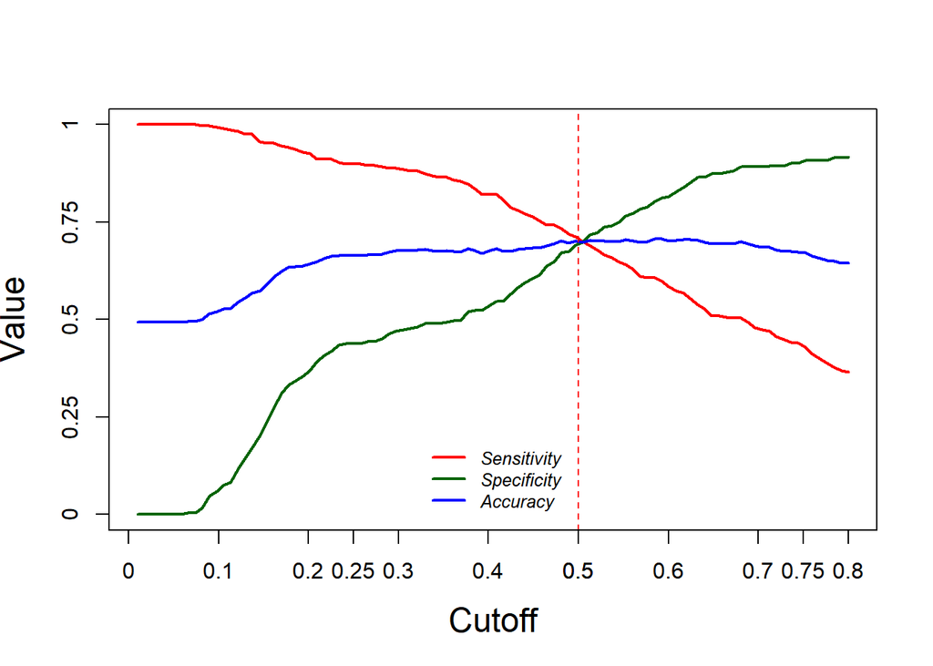

```r
options(repr.plot.width =8, repr.plot.height =6)
summary(pred)
s = seq(0.01,0.80,length=100)
OUT = matrix(0,100,3)

for(i in 1:100)
{
  OUT[i,] = perform_fn(s[i])
}
plot(s, OUT[,1],xlab="Cutoff",ylab="Value",cex.lab=1.5,cex.axis=1.5,ylim=c(0,1),
     type="l",lwd=2,axes=FALSE,col=2)
axis(1,seq(0,1,length=5),seq(0,1,length=5),cex.lab=1.5)
axis(2,seq(0,1,length=5),seq(0,1,length=5),cex.lab=1.5)
lines(s,OUT[,2],col="darkgreen",lwd=2)
lines(s,OUT[,3],col=4,lwd=2)
box()
legend("bottom",col=c(2,"darkgreen",4,"darkred"),text.font =3,inset = 0.02,
       box.lty=0,cex = 0.8,
       lwd=c(2,2,2,2),c("Sensitivity","Specificity","Accuracy"))
abline(v = 0.5, col="red", lwd=1, lty=2)
axis(1, at = seq(0.1, 1, by = 0.1))
```

The above chart shows the optimal cutoff value which will give maximum values for accuracy, sensitivity, specificity. Optimal cutoff value is 0.5

## Model Building 2 - Decision Tree

Splits the data into multiple sets and each set is further split into subsets to arrive at a tree like structure and make a decision. Homogeneity is the basic concept that helps to determine the attribute on which a split should be made. A split that results into the most homogenous subset is often considered better and step by step each attribute is choosen that maximizes the homogeneity of each subset. Further, this homogeneity is measured using different ways such as Gini Index, Entropy and Information Gain.

#### Training the Decision Tree model using all variables & Predicting in the validation data

```r
#Training
Dtree = rpart(Blood_Pressure_Abnormality ~., data = train, method = "class")
summary(Dtree)

#Predicting
DTPred <- predict(Dtree,type = "class", newdata = validation[,-1])
```

#### Checking the Confusion Matrix

```r
confusionMatrix(validation$Blood_Pressure_Abnormality, DTPred)
```

```
## Confusion Matrix and Statistics
##
##           Reference
## Prediction   0   1
##          0 246  58
##          1  27 269
##
##                Accuracy : 0.8583
##                  95% CI : (0.8278, 0.8852)
##     No Information Rate : 0.545
##     P-Value [Acc > NIR] : < 2.2e-16
##
##                   Kappa : 0.717
##  Mcnemar's Test P-Value : 0.001138
##
##             Sensitivity : 0.9011
##             Specificity : 0.8226
##          Pos Pred Value : 0.8092
##          Neg Pred Value : 0.9088
##              Prevalence : 0.4550
##          Detection Rate : 0.4100
##    Detection Prevalence : 0.5067
##       Balanced Accuracy : 0.8619
##
##        'Positive' Class : 0
##
```

The decision tree model (accuracy - 85%) gives very higher better accuracy with respect to the logistic regression model (accuracy 70%). The sensitivity is also better in case of Decision tree which is 90%. The specificity has also increased to 82% in case of Decision Tree as compared to logistic regression model.

## Model Building 3- Random Forest

Random Forest is often known as an ensemble of a large number of Decision Trees, that uses bootstrapped aggregation technique to choose random samples from a dataset to train each tree in the forest. The final prediction in a RandomForest is an aggregation of prediction of individual trees.

```r
model.rf <- randomForest(Blood_Pressure_Abnormality ~ ., data=train, proximity=FALSE,importance = FALSE,
                         ntree=500,mtry=4, do.trace=FALSE)
model.rf
```

```
##
## Call:
##  randomForest(formula = Blood_Pressure_Abnormality ~ ., data = train,      proximity = FALSE, importance = FALSE, ntree = 500, mtry = 4,      do.trace = FALSE)
##                Type of random forest: classification
##                      Number of trees: 500
## No. of variables tried at each split: 4
##
##         OOB estimate of  error rate: 11.79%
## Confusion matrix:
##     0   1 class.error
## 0 608 101  0.14245416
## 1  64 627  0.09261939
```

```r
#Predicting on the validation set and checking the Confusion Matrix.
testPred <- predict(model.rf, newdata=validation[,-1])
table(testPred, validation$Blood_Pressure_Abnormality)
```

```
##
## testPred   0   1
##        0 257  32
##        1  47 264
```

```r
confusionMatrix(validation$Blood_Pressure_Abnormality, testPred)
```

```
## Confusion Matrix and Statistics
##
##           Reference
## Prediction   0   1
##          0 257  47
##          1  32 264
##
##                Accuracy : 0.8683
##                  95% CI : (0.8386, 0.8944)
##     No Information Rate : 0.5183
##     P-Value [Acc > NIR] : <2e-16
##
##                   Kappa : 0.7368
##  Mcnemar's Test P-Value : 0.1152
##
##             Sensitivity : 0.8893
##             Specificity : 0.8489
##          Pos Pred Value : 0.8454
##          Neg Pred Value : 0.8919
##              Prevalence : 0.4817
##          Detection Rate : 0.4283
##    Detection Prevalence : 0.5067
##       Balanced Accuracy : 0.8691
##
##        'Positive' Class : 0
##
```

#### Variable Importance Plot

Generating variable importance plot, that shows the most significant attribute in decreasing order by mean decrease in Gini. The Mean decrease Gini measures how pure the nodes are at the end of the tree. Higher the Gini Index, better is the homogeneity.

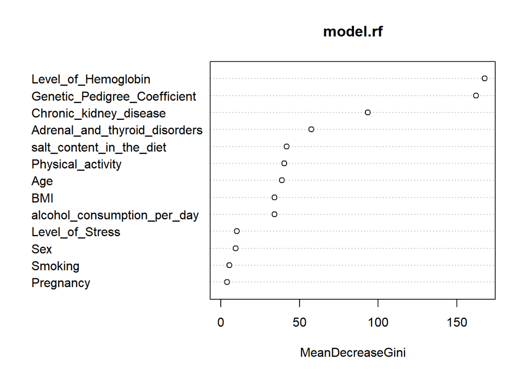

```r
#Checking the variable Importance Plot
varImpPlot(model.rf)
```

#### Checking the AUC for all three models:

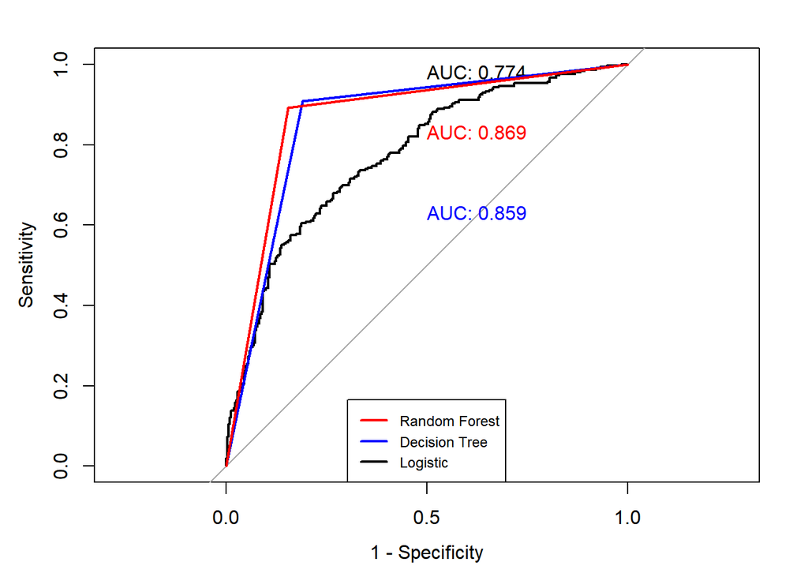

```r
options(repr.plot.width =10, repr.plot.height = 8)

glm.roc <- roc(response = validation$Blood_Pressure_Abnormality, predictor = as.numeric(pred))
DT.roc <- roc(response = validation$Blood_Pressure_Abnormality, predictor = as.numeric(DTPred))
rf.roc <- roc(response = validation$Blood_Pressure_Abnormality, predictor = as.numeric(testPred))

plot(glm.roc,      legacy.axes = TRUE, print.auc.y = 1.0, print.auc = TRUE)
plot(DT.roc, col = "blue", add = TRUE, print.auc.y = 0.65, print.auc = TRUE)
plot(rf.roc, col = "red" , add = TRUE, print.auc.y = 0.85, print.auc = TRUE)
legend("bottom", c("Random Forest", "Decision Tree", "Logistic"),
       lty = c(1,1), lwd = c(2, 2), col = c("red", "blue", "black"), cex = 0.75)
```

#### A brief Summary of all the models:

DecisionTrees:

- Accuracy 85.83%
- Sensitivity 90.11%
- Specificity 82.26%

#### Decision Trees performed better than Logistic Regression and slightly less than Random Forest. Since it is easy to interpret than Random Forest, selecting *Decision Trees* as final model.